# COVID-19 - Forecasting and compare machine learning models

Adrien BORDERON

01 July, 2020

Load the following libraries.

```r
library(tidyverse)
library(tidymodels)
library(modeltime)
library(timetk)
library(lubridate)
library(readr)
library(dplyr)
library(tidyr)
library(glmnet)
library(randomForest)
```

# Data on COVID-19 (coronavirus) by *Our World in Data*

COVID-19 dataset is a collection of the COVID-19 data maintained by [*Our World in Data*](https://ourworldindata.org/coronavirus). It is updated daily and includes data on confirmed cases, deaths, and testing, as well as other variables of potential interest.

We’ll start with a covid daily time series data set that includes **new daily cases**. We’ll simplify the data set to a univariate time series with columns, “date” and “value”.

```r
data_daily  <- read.csv("~/Workdir/COVID-19-models-forecasting/data/owid-covid-data.csv")
data_daily <- data_daily %>% select(date, new_cases) %>% drop_na(new_cases)

time_series_covid19_confirmed_global <- aggregate(data_daily$new_cases, by=list(date=data_daily$date), FUN=sum)

covid19_confirmed_global_tbl <- time_series_covid19_confirmed_global %>%
  select(date, x) %>%
  rename(value=x)

covid19_confirmed_global_tbl$date <- as.Date(covid19_confirmed_global_tbl$date, format = "%Y-%m-%d")
covid19_confirmed_global_tbl <- covid19_confirmed_global_tbl[covid19_confirmed_global_tbl[["date"]] >= "2020-01-17", ]

covid19_confirmed_global_tbl <- as.tibble(covid19_confirmed_global_tbl)
covid19_confirmed_global_tbl
```

| date | value |
| --- | --- |
| 2020-01-17 | 10 |
| 2020-01-18 | 34 |
| 2020-01-19 | 272 |
| 2020-01-20 | 40 |
| 2020-01-21 | 306 |
| 2020-01-22 | 284 |
| 2020-01-23 | 194 |
| 2020-01-24 | 532 |
| 2020-01-25 | 906 |
| 2020-01-26 | 1346 |

[output cut: 156 more lines]

## Show COVID-19 new daily cases

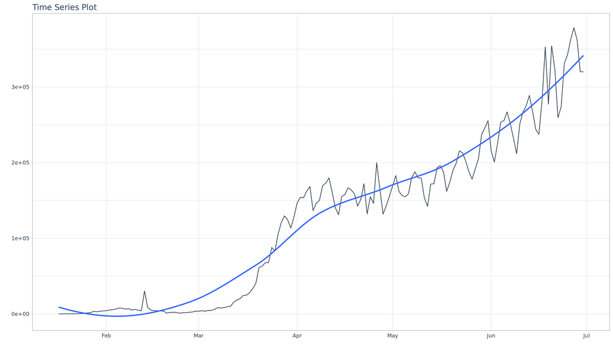

```r
covid19_confirmed_global_tbl %>%
  plot_time_series(date, value, .interactive = FALSE)
```

# Train / Test

Split time series into training and testing sets. We use the last ****5 days** of data as the testing set.

## Train/test split time serie

```r
splits <- covid19_confirmed_global_tbl %>%
  time_series_split(assess = "5 days", cumulative = TRUE)
```

```
## Using date_var: date
```

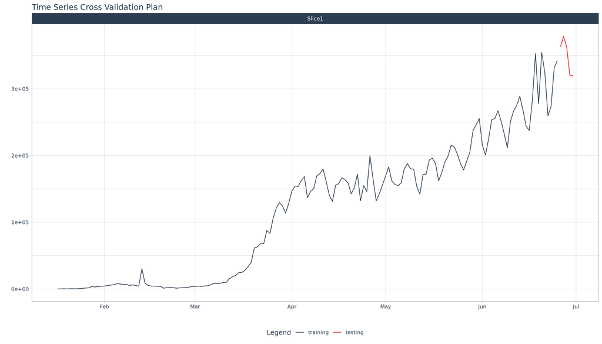

```r
splits %>%
  tk_time_series_cv_plan() %>%
  plot_time_series_cv_plan(date, value, .interactive = FALSE)
```

# Modeling

## Automatic Models

Several models to see this process :

### Auto ARIMA

Auto Arima Model fitting process.

```r
model_fit_arima <- arima_reg() %>%
  set_engine("auto_arima") %>%
  fit(value ~ date, training(splits))
```

```
## frequency = 7 observations per 1 week
```

```r
model_fit_arima
```

```
## parsnip model object
##
## Fit time:  342ms
## Series: outcome
## ARIMA(2,1,2)(0,0,2)[7] with drift
##
## Coefficients:
##          ar1      ar2      ma1     ma2    sma1    sma2      drift
##       1.0928  -0.5854  -1.6122  0.8593  0.1954  0.3654  2001.7886
## s.e.  0.0932   0.0879   0.0692  0.0662  0.1019  0.0941   858.2301
##
## sigma^2 estimated as 2.12e+08:  log likelihood=-1759.24
## AIC=3534.47   AICc=3535.43   BIC=3559.08
```

### Prophet

Prophet Model fitting process.

```r
model_fit_prophet <- prophet_reg() %>%
  set_engine("prophet", yearly.seasonality = TRUE) %>%
  fit(value ~ date, training(splits))
```

```
## Disabling daily seasonality. Run prophet with daily.seasonality=TRUE to override this.
```

```r
model_fit_prophet
```

```
## parsnip model object
##
## Fit time:  61ms
## PROPHET Model
## - growth: 'linear'
## - n.changepoints: 25
## - seasonality.mode: 'additive'
## - extra_regressors: 0
```

## Machine Learning Models

### Preprocessing Recipe

```r
recipe_spec <- recipe(value ~ date, training(splits)) %>%
  step_timeseries_signature(date) %>%
  step_rm(contains("am.pm"), contains("hour"), contains("minute"),
          contains("second"), contains("xts")) %>%
  step_fourier(date, period = 365, K = 5) %>%
  step_dummy(all_nominal())

recipe_spec %>% prep() %>% juice()
```

| date | value | date_index.num | date_year | date_year.iso | date_half | date_quarter | date_month | date_day | date_wday | date_mday | date_qday | date_yday | date_mweek | date_week | date_week.iso | date_week2 | date_week3 | date_week4 | date_mday7 | date_sin365_K1 | date_cos365_K1 | date_sin365_K2 | date_cos365_K2 | date_sin365_K3 | date_cos365_K3 | date_sin365_K4 | date_cos365_K4 | date_sin365_K5 | date_cos365_K5 | … |
| --- | --- | --- | --- | --- | --- | --- | --- | --- | --- | --- | --- | --- | --- | --- | --- | --- | --- | --- | --- | --- | --- | --- | --- | --- | --- | --- | --- | --- | --- | --- |
| 2020-01-17 | 10 | 1579219200 | 2020 | 2020 | 1 | 1 | 1 | 17 | 6 | 17 | 17 | 17 | 3 | 3 | 3 | 1 | 0 | 3 | 3 | 0.463550271 | 0.886070622 | 0.821476553 | 0.570242293 | 0.992222209 | 0.124479264 | 0.936881346 | -0.349647455 | 6.680639e-01 | -0.74410394 | … |
| 2020-01-18 | 34 | 1579305600 | 2020 | 2020 | 1 | 1 | 1 | 18 | 7 | 18 | 18 | 18 | 3 | 3 | 3 | 1 | 0 | 3 | 3 | 0.478733840 | 0.877960085 | 0.840618406 | 0.541627821 | 0.997324973 | 0.073095130 | 0.910604630 | -0.413278608 | 6.016241e-01 | -0.79877937 | … |
| 2020-01-19 | 272 | 1579392000 | 2020 | 2020 | 1 | 1 | 1 | 19 | 1 | 19 | 19 | 19 | 3 | 3 | 3 | 1 | 0 | 3 | 3 | 0.493775550 | 0.869589389 | 0.858763958 | 0.512371412 | 0.999768502 | 0.021516097 | 0.880012204 | -0.474951072 | 5.307300e-01 | -0.84754092 | … |
| 2020-01-20 | 40 | 1579478400 | 2020 | 2020 | 1 | 1 | 1 | 20 | 2 | 20 | 20 | 20 | 4 | 3 | 4 | 1 | 0 | 3 | 3 | 0.508670944 | 0.860961016 | 0.875891705 | 0.482507742 | 0.999546281 | -0.030120305 | 0.845249057 | -0.534372558 | 4.559067e-01 | -0.89002758 | … |
| 2020-01-21 | 306 | 1579564800 | 2020 | 2020 | 1 | 1 | 1 | 21 | 3 | 21 | 21 | 21 | 4 | 3 | 4 | 1 | 0 | 3 | 4 | 0.523415607 | 0.852077521 | 0.891981346 | 0.452072204 | 0.996658902 | -0.081676395 | 0.806479946 | -0.591261445 | 3.777080e-01 | -0.92592478 | … |
| 2020-01-22 | 284 | 1579651200 | 2020 | 2020 | 1 | 1 | 1 | 22 | 4 | 22 | 22 | 22 | 4 | 4 | 4 | 0 | 1 | 0 | 4 | 0.538005172 | 0.842941537 | 0.907013813 | 0.421100871 | 0.991114064 | -0.133014707 | 0.763888613 | -0.645348113 | 2.967128e-01 | -0.95496675 | … |
| 2020-01-23 | 194 | 1579737600 | 2020 | 2020 | 1 | 1 | 1 | 23 | 5 | 23 | 23 | 23 | 4 | 4 | 4 | 0 | 1 | 0 | 4 | 0.552435313 | 0.833555772 | 0.920971288 | 0.389630450 | 0.982926552 | -0.183998352 | 0.717676914 | -0.696376226 | 2.135209e-01 | -0.97693849 | … |
| 2020-01-24 | 532 | 1579824000 | 2020 | 2020 | 1 | 1 | 1 | 24 | 6 | 24 | 24 | 24 | 4 | 4 | 4 | 0 | 1 | 0 | 4 | 0.566701756 | 0.823923006 | 0.933837229 | 0.357698239 | 0.972118197 | -0.234491390 | 0.668063864 | -0.744103940 | 1.287482e-01 | -0.99167732 | … |
| 2020-01-25 | 906 | 1579910400 | 2020 | 2020 | 1 | 1 | 1 | 25 | 7 | 25 | 25 | 25 | 4 | 4 | 4 | 0 | 1 | 0 | 4 | 0.580800273 | 0.814046094 | 0.945596387 | 0.325342085 | 0.958717817 | -0.284359187 | 0.615284600 | -0.788305056 | 4.302223e-02 | -0.99907412 | … |
| 2020-01-26 | 1346 | 1579996800 | 2020 | 2020 | 1 | 1 | 1 | 26 | 1 | 26 | 26 | 26 | 4 | 4 | 4 | 0 | 1 | 0 | 4 | 0.594726687 | 0.803927962 | 0.956234827 | 0.292600336 | 0.942761143 | -0.333468779 | 0.559589262 | -0.828770087 | -4.302223e-02 | -0.99907412 | … |

[output cut: 151 more lines]

With a recipe in-hand, we can set up our machine learning pipelines.

### Elastic Net

Making an Elastic NET model

```r
model_spec_glmnet <- linear_reg(penalty = 0.01, mixture = 0.5) %>%
  set_engine("glmnet")
```

Fitted workflow

```r
workflow_fit_glmnet <- workflow() %>%
  add_model(model_spec_glmnet) %>%
  add_recipe(recipe_spec %>% step_rm(date)) %>%
  fit(training(splits))
```

### Random Forest

Fit a Random Forest

```r
model_spec_rf <- rand_forest(trees = 500, min_n = 50) %>%
  set_engine("randomForest")

workflow_fit_rf <- workflow() %>%
  add_model(model_spec_rf) %>%
  add_recipe(recipe_spec %>% step_rm(date)) %>%
  fit(training(splits))
```

### Prophet Boost

Set the model up using a workflow

```r
model_spec_prophet_boost <- prophet_boost() %>%
  set_engine("prophet_xgboost", yearly.seasonality = TRUE)

workflow_fit_prophet_boost <- workflow() %>%
  add_model(model_spec_prophet_boost) %>%
  add_recipe(recipe_spec) %>%
  fit(training(splits))
```

```
## Disabling daily seasonality. Run prophet with daily.seasonality=TRUE to override this.
```

[output not shown]

```r
workflow_fit_prophet_boost
```

```
## ══ Workflow [trained] ══════════════════════════════════════════════════════════════════════════════════════════════════════════════════════════════════════════════════════
## Preprocessor: Recipe
## Model: prophet_boost()
##
## ── Preprocessor ────────────────────────────────────────────────────────────────────────────────────────────────────────────────────────────────────────────────────────────
## 4 Recipe Steps
##
## ● step_timeseries_signature()
## ● step_rm()
## ● step_fourier()
## ● step_dummy()
##
## ── Model ───────────────────────────────────────────────────────────────────────────────────────────────────────────────────────────────────────────────────────────────────
## PROPHET w/ XGBoost Errors
## ---
## Model 1: PROPHET
## - growth: 'linear'
## - n.changepoints: 25
## - seasonality.mode: 'additive'
##
## ---
## Model 2: XGBoost Errors
##
## xgboost::xgb.train(params = list(eta = 0.3, max_depth = 6, gamma = 0,
##     colsample_bytree = 1, min_child_weight = 1, subsample = 1),
##     data = x, nrounds = 15, early_stopping_rounds = NULL, objective = "reg:squarederror",
##     validation = 0)
```

# Model evaluation and selection

Organize the models with IDs and creates generic descriptions.

```r
model_table <- modeltime_table(
  model_fit_arima,
  model_fit_prophet,
  workflow_fit_glmnet,
  workflow_fit_rf,
  workflow_fit_prophet_boost
)

model_table
```

| .model_id | .model | .model_desc |
| --- | --- | --- |
| 1 |  | ARIMA(2,1,2)(0,0,2)[7] WITH DRIFT |
| 2 |  | PROPHET |
| 3 |  | GLMNET |
| 4 |  | RANDOMFOREST |
| 5 |  | PROPHET W/ XGBOOST ERRORS |

## Calibration

Quantify error and estimate confidence intervals.

```r
calibration_table <- model_table %>%
  modeltime_calibrate(testing(splits))

calibration_table
```

| .model_id | .model | .model_desc | .type | .calibration_data |
| --- | --- | --- | --- | --- |
| 1 |  | ARIMA(2,1,2)(0,0,2)[7] WITH DRIFT | Test |  |
| 2 |  | PROPHET | Test |  |
| 3 |  | GLMNET | Test |  |
| 4 |  | RANDOMFOREST | Test |  |
| 5 |  | PROPHET W/ XGBOOST ERRORS | Test |  |

# Forecast (Testing Set)

Visualize the testing predictions (forecast).

```
## 'new_data' is missing. Using '.calibration_data' to forecast.
```

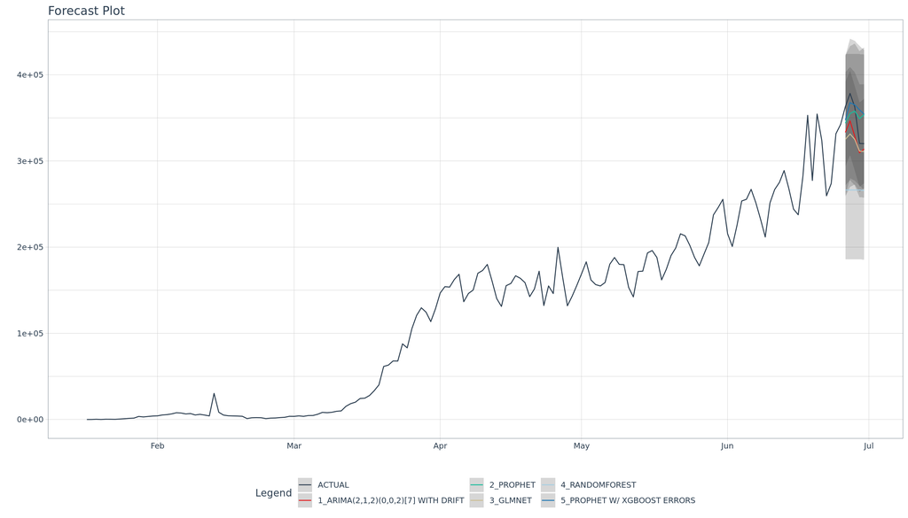

```r
calibration_table %>%
  modeltime_forecast(actual_data = covid19_confirmed_global_tbl) %>%
  plot_modeltime_forecast(.interactive = FALSE)
```

## Accuracy (Testing Set)

Calculate the testing accuracy to compare the models.

```r
calibration_table %>%
  modeltime_accuracy() %>%
  table_modeltime_accuracy(.interactive = FALSE)
```

Accuracy Table

| .model_id | .model_desc | .type | mae | mape | mase | smape | rmse | rsq |
| --- | --- | --- | --- | --- | --- | --- | --- | --- |
| 1 | ARIMA(2,1,2)(0,0,2)[7] WITH DRIFT | Test | 22526.77 | 6.26 | 1.22 | 6.51 | 25367.86 | 0.94 |
| 2 | PROPHET | Test | 21943.96 | 6.45 | 1.19 | 6.34 | 24090.94 | 0.02 |
| 3 | GLMNET | Test | 28088.56 | 7.77 | 1.53 | 8.18 | 32302.35 | 1.00 |
| 4 | RANDOMFOREST | Test | 82702.35 | 23.34 | 4.49 | 26.62 | 86107.41 | 0.36 |
| 5 | PROPHET W/ XGBOOST ERRORS | Test | 20410.54 | 6.14 | 1.11 | 5.92 | 24731.97 | 0.12 |

## Analyze Results

# Refit and Forecast Forward (Global in world)

```
## frequency = 7 observations per 1 week
```

```
## Disabling daily seasonality. Run prophet with daily.seasonality=TRUE to override this.
## Disabling daily seasonality. Run prophet with daily.seasonality=TRUE to override this.
```

[output not shown]

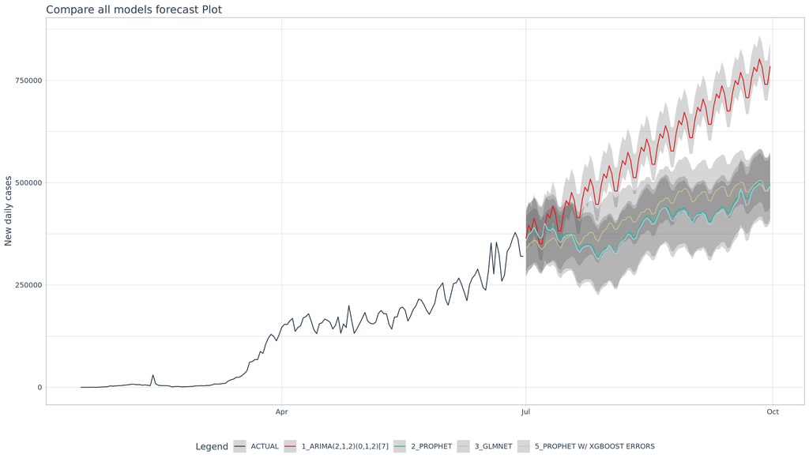

```r
calibration_table %>%
  # Remove RANDOMFOREST model with low accuracy
  filter(.model_id != 4) %>%

  # Refit and Forecast Forward
  modeltime_refit(covid19_confirmed_global_tbl) %>%
  modeltime_forecast(h = "3 months", actual_data = covid19_confirmed_global_tbl) %>%
  plot_modeltime_forecast(.interactive = FALSE, .title = "Compare all models forecast Plot", .y_lab = "New daily cases")
```

## ARIMA model forecast

```
## frequency = 7 observations per 1 week
```

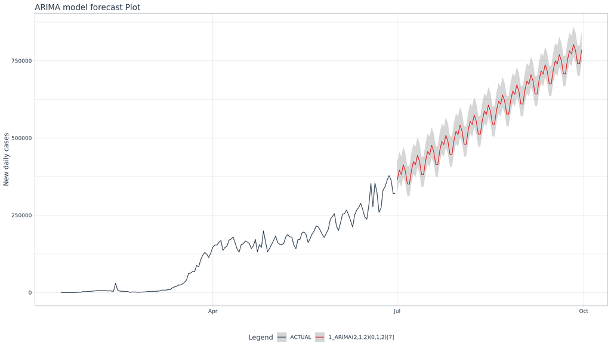

```r
calibration_table %>%
  filter(.model_id == 1) %>%
  # Refit and Forecast Forward
  modeltime_refit(covid19_confirmed_global_tbl) %>%
  modeltime_forecast(h = "3 months", actual_data = covid19_confirmed_global_tbl) %>%
  plot_modeltime_forecast(.interactive = FALSE, .title = "ARIMA model forecast Plot", .y_lab = "New daily cases")
```

## PROPHET model forecast

```
## Disabling daily seasonality. Run prophet with daily.seasonality=TRUE to override this.
```

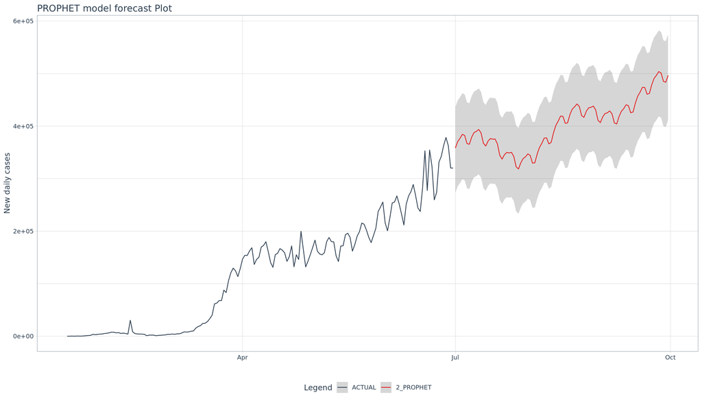

```r
calibration_table %>%
  filter(.model_id == 2) %>%
  # Refit and Forecast Forward
  modeltime_refit(covid19_confirmed_global_tbl) %>%
  modeltime_forecast(h = "3 months", actual_data = covid19_confirmed_global_tbl) %>%
  plot_modeltime_forecast(.interactive = FALSE, .title = "PROPHET model forecast Plot", .y_lab = "New daily cases")
```

## GLMNET model forecast

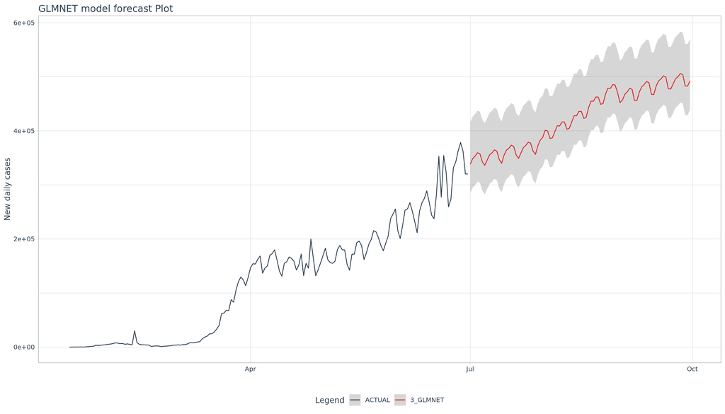

```r
calibration_table %>%
  filter(.model_id == 3) %>%
  # Refit and Forecast Forward
  modeltime_refit(covid19_confirmed_global_tbl) %>%
  modeltime_forecast(h = "3 months", actual_data = covid19_confirmed_global_tbl) %>%
  plot_modeltime_forecast(.interactive = FALSE, .title = "GLMNET model forecast Plot", .y_lab = "New daily cases")
```

## PROPHET + XGBOOST model forecast

```
## Disabling daily seasonality. Run prophet with daily.seasonality=TRUE to override this.
```

[output not shown]

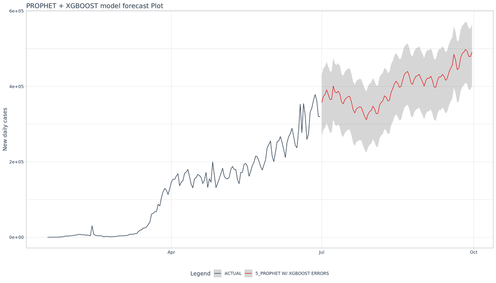

```r
calibration_table %>%
  filter(.model_id == 5) %>%
  # Refit and Forecast Forward
  modeltime_refit(covid19_confirmed_global_tbl) %>%
  modeltime_forecast(h = "3 months", actual_data = covid19_confirmed_global_tbl) %>%
  plot_modeltime_forecast(.interactive = FALSE, .title = "PROPHET + XGBOOST model forecast Plot", .y_lab = "New daily cases")
```

# Data on COVID-19 (coronavirus) only in FRANCE

Filter COVID-19 dataset in **France**.

| date | value |
| --- | --- |
| 2020-02-26 | 2 |
| 2020-02-27 | 3 |
| 2020-02-28 | 21 |
| 2020-02-29 | 19 |
| 2020-03-01 | 43 |
| 2020-03-02 | 30 |
| 2020-03-03 | 48 |
| 2020-03-04 | 34 |
| 2020-03-05 | 73 |
| 2020-03-06 | 138 |

[output cut: 116 more lines]

## Show FRANCE COVID-19 new daily cases

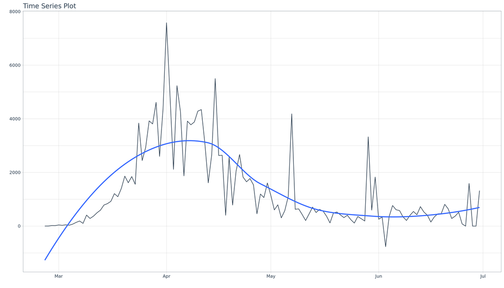

# Train / Test

## Train/test split time serie

```
## Using date_var: date
```

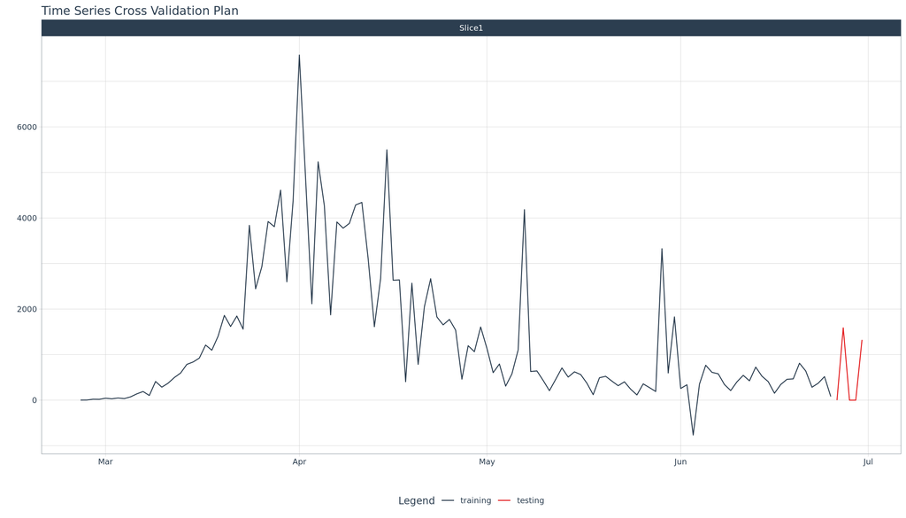

# Modeling

## Automatic Models

### Auto ARIMA

Auto Arima Model fitting process.

```r
model_fit_arima <- arima_reg() %>%
  set_engine("auto_arima") %>%
  fit(value ~ date, training(splits))
```

```
## frequency = 7 observations per 1 week
```

```r
model_fit_arima
```

```
## parsnip model object
##
## Fit time:  527ms
## Series: outcome
## ARIMA(0,1,1)(0,0,2)[7]
##
## Coefficients:
##           ma1    sma1    sma2
##       -0.6935  0.1816  0.2081
## s.e.   0.0590  0.0874  0.0886
##
## sigma^2 estimated as 816656:  log likelihood=-986.23
## AIC=1980.47   AICc=1980.82   BIC=1991.62
```

### Prophet

Prophet Model fitting process.

```r
model_fit_prophet <- prophet_reg() %>%
  set_engine("prophet", yearly.seasonality = TRUE) %>%
  fit(value ~ date, training(splits))
```

```
## Disabling daily seasonality. Run prophet with daily.seasonality=TRUE to override this.
```

```r
model_fit_prophet
```

```
## parsnip model object
##
## Fit time:  55ms
## PROPHET Model
## - growth: 'linear'
## - n.changepoints: 25
## - seasonality.mode: 'additive'
## - extra_regressors: 0
```

## Machine Learning Models

### Preprocessing Recipe

| date | value | date_index.num | date_year | date_year.iso | date_half | date_quarter | date_month | date_day | date_wday | date_mday | date_qday | date_yday | date_mweek | date_week | date_week.iso | date_week2 | date_week3 | date_week4 | date_mday7 | date_sin365_K1 | date_cos365_K1 | date_sin365_K2 | date_cos365_K2 | date_sin365_K3 | date_cos365_K3 | date_sin365_K4 | date_cos365_K4 | date_sin365_K5 | date_cos365_K5 | … |
| --- | --- | --- | --- | --- | --- | --- | --- | --- | --- | --- | --- | --- | --- | --- | --- | --- | --- | --- | --- | --- | --- | --- | --- | --- | --- | --- | --- | --- | --- | --- |
| 2020-02-26 | 2 | 1582675200 | 2020 | 2020 | 1 | 1 | 2 | 26 | 4 | 26 | 57 | 57 | 5 | 9 | 9 | 1 | 0 | 1 | 4 | 0.920971288 | 0.389630450 | 0.717676914 | -0.696376226 | -0.36171373 | -0.932289213 | -0.999546281 | -0.030120305 | -4.171936e-01 | 0.90881764 | … |
| 2020-02-27 | 3 | 1582761600 | 2020 | 2020 | 1 | 1 | 2 | 27 | 5 | 27 | 58 | 58 | 5 | 9 | 9 | 1 | 0 | 1 | 4 | 0.927541684 | 0.373719715 | 0.693281227 | -0.720667150 | -0.40935596 | -0.912374758 | -0.999250011 | 0.038722281 | -3.375229e-01 | 0.94131732 | … |
| 2020-02-28 | 21 | 1582848000 | 2020 | 2020 | 1 | 1 | 2 | 28 | 6 | 28 | 59 | 59 | 5 | 9 | 9 | 1 | 0 | 1 | 5 | 0.933837229 | 0.357698239 | 0.668063864 | -0.744103940 | -0.45590669 | -0.890027576 | -0.994217907 | 0.107381347 | -2.553533e-01 | 0.96684781 | … |
| 2020-02-29 | 19 | 1582934400 | 2020 | 2020 | 1 | 1 | 2 | 29 | 7 | 29 | 60 | 60 | 5 | 9 | 9 | 1 | 0 | 1 | 5 | 0.939856058 | 0.341570769 | 0.642054713 | -0.766658819 | -0.50124181 | -0.865307254 | -0.984473817 | 0.175531490 | -1.712931e-01 | 0.98522011 | … |
| 2020-03-01 | 43 | 1583020800 | 2020 | 2020 | 1 | 1 | 3 | 1 | 1 | 1 | 61 | 61 | 1 | 9 | 9 | 1 | 0 | 1 | 1 | 0.945596387 | 0.325342085 | 0.615284600 | -0.788305056 | -0.54524044 | -0.838279705 | -0.970063922 | 0.242849722 | -8.596480e-02 | 0.99629817 | … |
| 2020-03-02 | 30 | 1583107200 | 2020 | 2020 | 1 | 1 | 3 | 2 | 2 | 2 | 62 | 62 | 2 | 9 | 10 | 1 | 0 | 1 | 1 | 0.951056516 | 0.309016994 | 0.587785252 | -0.809016994 | -0.58778525 | -0.809016994 | -0.951056516 | 0.309016994 | 4.510414e-14 | 1.00000000 | … |
| 2020-03-03 | 48 | 1583193600 | 2020 | 2020 | 1 | 1 | 3 | 3 | 3 | 3 | 63 | 63 | 2 | 9 | 10 | 1 | 0 | 1 | 1 | 0.956234827 | 0.292600336 | 0.559589262 | -0.828770087 | -0.62876281 | -0.777597147 | -0.927541684 | 0.373719715 | 8.596480e-02 | 0.99629817 | … |
| 2020-03-04 | 34 | 1583280000 | 2020 | 2020 | 1 | 1 | 3 | 4 | 4 | 4 | 64 | 64 | 2 | 10 | 10 | 0 | 1 | 2 | 1 | 0.961129784 | 0.276096973 | 0.530730048 | -0.847540923 | -0.66806386 | -0.744103940 | -0.899630870 | 0.436651232 | 1.712931e-01 | 0.98522011 | … |
| 2020-03-05 | 73 | 1583366400 | 2020 | 2020 | 1 | 1 | 3 | 5 | 5 | 5 | 65 | 65 | 2 | 10 | 10 | 0 | 1 | 2 | 1 | 0.965739938 | 0.259511797 | 0.501241813 | -0.865307254 | -0.70558361 | -0.708626678 | -0.867456355 | 0.497513289 | 2.553533e-01 | 0.96684781 | … |
| 2020-03-06 | 138 | 1583452800 | 2020 | 2020 | 1 | 1 | 3 | 6 | 6 | 6 | 66 | 66 | 2 | 10 | 10 | 0 | 1 | 2 | 1 | 0.970063922 | 0.242849722 | 0.471159508 | -0.882048025 | -0.74122201 | -0.671259958 | -0.831170626 | 0.556017437 | 3.375229e-01 | 0.94131732 | … |

[output cut: 111 more lines]

### Elastic Net

Making an Elastic NET model

```r
model_spec_glmnet <- linear_reg(penalty = 0.01, mixture = 0.5) %>%
  set_engine("glmnet")
```

Fitted workflow

```r
workflow_fit_glmnet <- workflow() %>%
  add_model(model_spec_glmnet) %>%
  add_recipe(recipe_spec %>% step_rm(date)) %>%
  fit(training(splits))
```

### Random Forest

Fit a Random Forest

### Prophet Boost

Set the model up using a workflow

```
## Disabling daily seasonality. Run prophet with daily.seasonality=TRUE to override this.
```

[output not shown]

```
## ══ Workflow [trained] ══════════════════════════════════════════════════════════════════════════════════════════════════════════════════════════════════════════════════════
## Preprocessor: Recipe
## Model: prophet_boost()
##
## ── Preprocessor ────────────────────────────────────────────────────────────────────────────────────────────────────────────────────────────────────────────────────────────
## 4 Recipe Steps
##
## ● step_timeseries_signature()
## ● step_rm()
## ● step_fourier()
## ● step_dummy()
##
## ── Model ───────────────────────────────────────────────────────────────────────────────────────────────────────────────────────────────────────────────────────────────────
## PROPHET w/ XGBoost Errors
## ---
## Model 1: PROPHET
## - growth: 'linear'
## - n.changepoints: 25
## - seasonality.mode: 'additive'
##
## ---
## Model 2: XGBoost Errors
##
## xgboost::xgb.train(params = list(eta = 0.3, max_depth = 6, gamma = 0,
##     colsample_bytree = 1, min_child_weight = 1, subsample = 1),
##     data = x, nrounds = 15, early_stopping_rounds = NULL, objective = "reg:squarederror",
##     validation = 0)
```

# Model evaluation and selection

Organize the models with IDs and creates generic descriptions.

| .model_id | .model | .model_desc |
| --- | --- | --- |
| 1 |  | ARIMA(0,1,1)(0,0,2)[7] |
| 2 |  | PROPHET |
| 3 |  | GLMNET |
| 4 |  | RANDOMFOREST |
| 5 |  | PROPHET W/ XGBOOST ERRORS |

## Calibration

Quantify error and estimate confidence intervals.

| .model_id | .model | .model_desc | .type | .calibration_data |
| --- | --- | --- | --- | --- |
| 1 |  | ARIMA(0,1,1)(0,0,2)[7] | Test |  |
| 2 |  | PROPHET | Test |  |
| 3 |  | GLMNET | Test |  |
| 4 |  | RANDOMFOREST | Test |  |
| 5 |  | PROPHET W/ XGBOOST ERRORS | Test |  |

# FRANCE Forecast (Testing Set)

Visualize the testing predictions (forecast).

```
## 'new_data' is missing. Using '.calibration_data' to forecast.
```

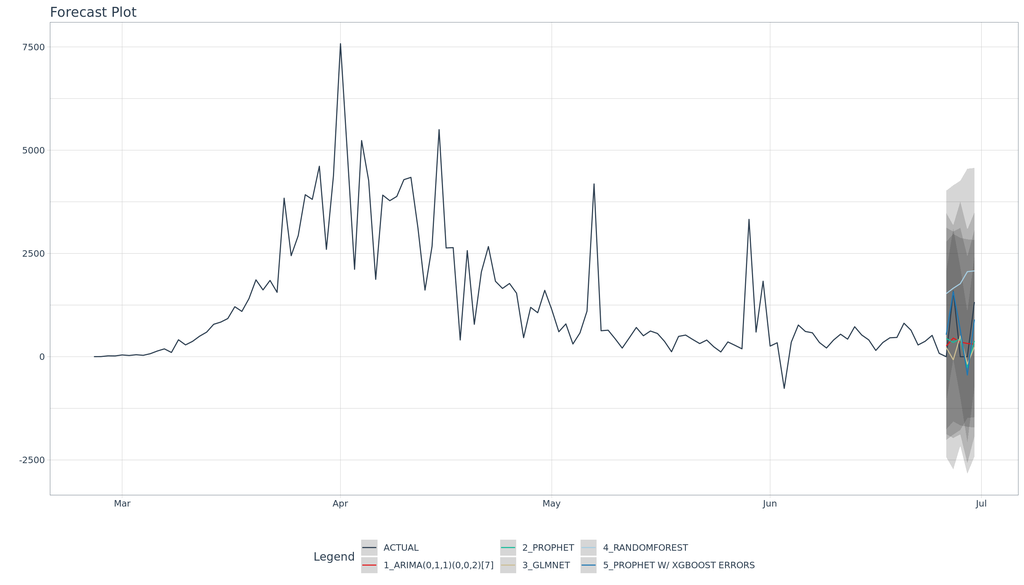

## Accuracy (Testing Set)

Calculate the testing accuracy to compare the models.

Accuracy Table

| .model_id | .model_desc | .type | mae | mape | mase | smape | rmse | rsq |
| --- | --- | --- | --- | --- | --- | --- | --- | --- |
| 1 | ARIMA(0,1,1)(0,0,2)[7] | Test | 618.20 | Inf | 0.55 | 167.35 | 724.97 | 0.34 |
| 2 | PROPHET | Test | 664.69 | Inf | 0.59 | 167.73 | 759.30 | 0.08 |
| 3 | GLMNET | Test | 730.82 | Inf | 0.65 | 187.91 | 925.11 | 0.06 |
| 4 | RANDOMFOREST | Test | 1235.75 | Inf | 1.10 | 129.72 | 1433.47 | 0.01 |
| 5 | PROPHET W/ XGBOOST ERRORS | Test | 409.69 | Inf | 0.36 | 127.77 | 461.89 | 0.61 |

## Analyze Results

From the accuracy measures and forecast results, we see that:

- RANDOMFOREST model is not a good fit for this data.
- The best model is PROPHET W/ XGBOOST ERRORS Let’s exclude the RANDOMFOREST from our final model, then make future forecasts with the remaining models.

# Refit and Forecast Forward (FRANCE ONLY)

```
## frequency = 7 observations per 1 week
```

```
## Disabling daily seasonality. Run prophet with daily.seasonality=TRUE to override this.
## Disabling daily seasonality. Run prophet with daily.seasonality=TRUE to override this.
```

[output not shown]

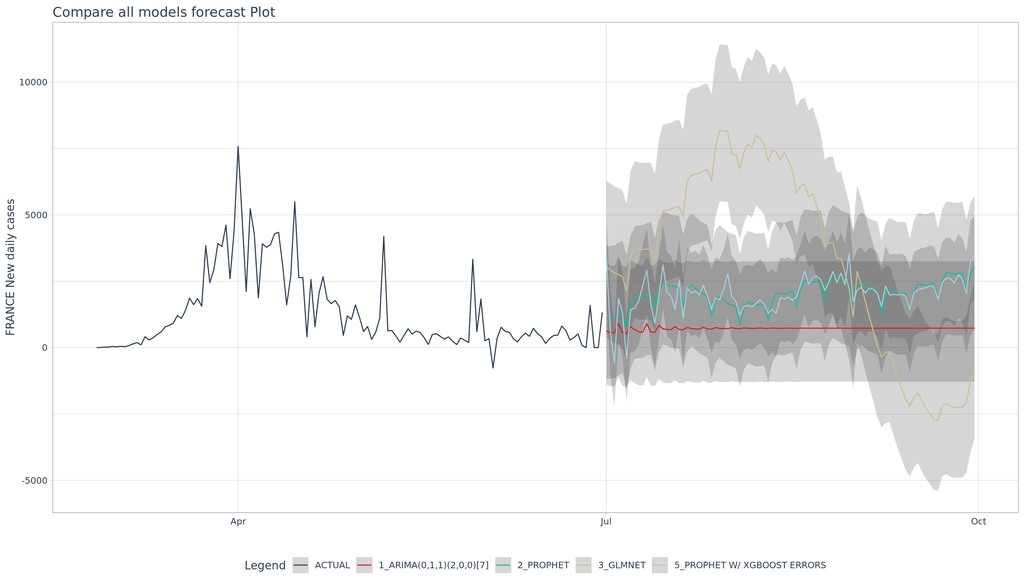

## ARIMA model forecast

```
## frequency = 7 observations per 1 week
```

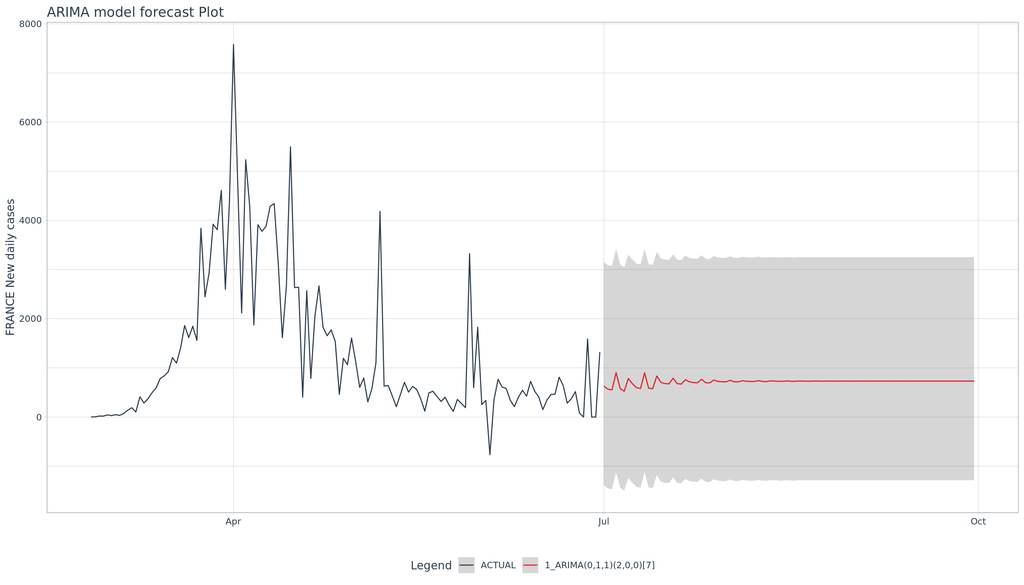

## PROPHET model forecast

```
## Disabling daily seasonality. Run prophet with daily.seasonality=TRUE to override this.
```

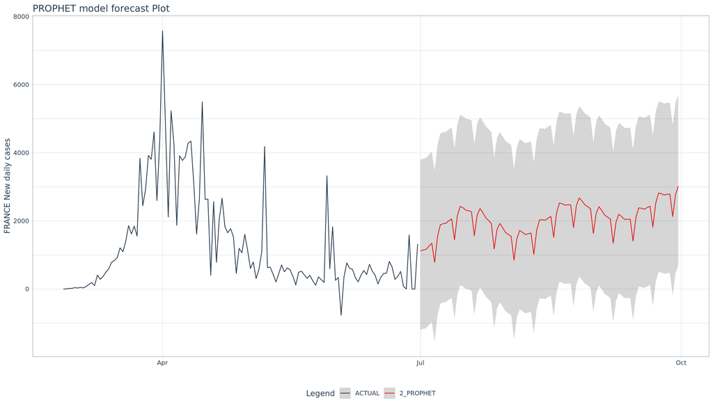

## GLMNET model forecast

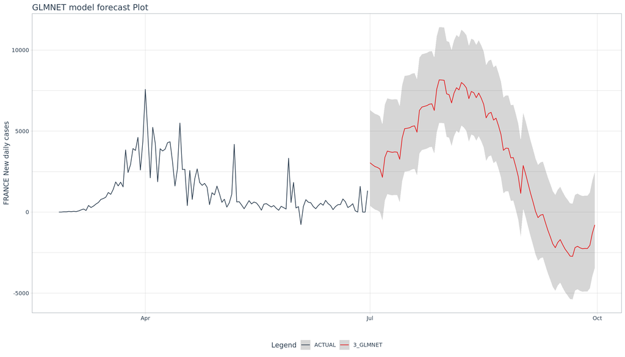

## PROPHET + XGBOOST model forecast

```
## Disabling daily seasonality. Run prophet with daily.seasonality=TRUE to override this.
```

[output not shown]

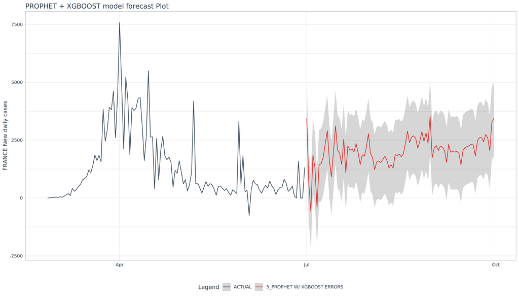